# Exploring Adult Earnings

Jamie McLaughlin

2022-08-22

## Abstract

This project is a sample project designed to investigate RMarkdown to a much fuller extent than previously. Utilising different techniques in Javascript (including D3), CSS, HTML and R itself to produce outputs of general interest. The work is considered to be an exploratory data analysis (EDA) and not to provide any sort of output. It is simply an effort to understand - to a greater degree - how to build better markdown documents.

## Introduction

In order to better understand R Markdown, a project has been undertaken to break down and investigate a medium-sized dataset with potential for further investigation at a later date. A useful resource for this is the celebrated UCI Machine Learning Repository, hosted by the Bren School of Information and Computer Science at the University of California, Irvine. The full selection of datasets available are found at https://archive.ics.uci.edu/ml/datasets.php and are categorised for simplicity of selection and use case using year, number of records and features, data types and default task (with the implication being that the dataset is well-suited to those particular tasks).

### Adult Earnings Classification Dataset

The ‘Adult’ dataset, found at https://archive.ics.uci.edu/ml/datasets/Adult, is a multivariate dataset donated in 1996 and derived from US census data. It features almost 50,000 records across 14 features. It does have some missing data - most of which is tidily organised (being recorded as ‘?’ for categorical variables).

## Visualisation and Investigation

In order to best get a basic ‘look’ at the data themselves, a visualisation was produced that plots some of the most interesting information in one place - split by explanatory and response variables. The dark blue bars represent those individuals earning over $50,000 and the orange bars representing individuals earning $50,000 or less:

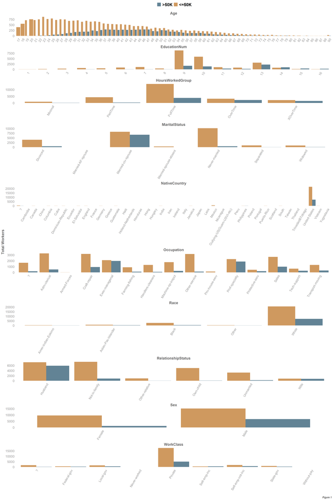

Breaking down some of the more interesting elements, there are some very clear changes in distribution across some of the explanatory variables. **Age**, for example, has a clear long-tailed, right-skew distribution of age for low earners (income $50,000 or less), but a more normal distribution with a higher mean for high earners (income over $50,000). **EducationNum**, which is an ordinal variable representing the highest attained level of education in a record, seems to have larger ‘chunks’ of high earners at higher values - suggesting higher educational attainment may be related to a higher level of income. **HoursWorkedGroup** is a variable created from *HoursWorked* where the hours have been binned into:

- Minimal (<15 hours)
- PartTime (<35 hours)
- FullTime (<45 hours)
- OverTime (<52 hours)
- XOverTime (>=52 hours).

## Potential Relationships

### Age

We begin by producing a jitter plot to visualise the relationship between *Age* and *High/Low Earners*. It’s quite clear that the average age of high earners is higher than that of low earners:

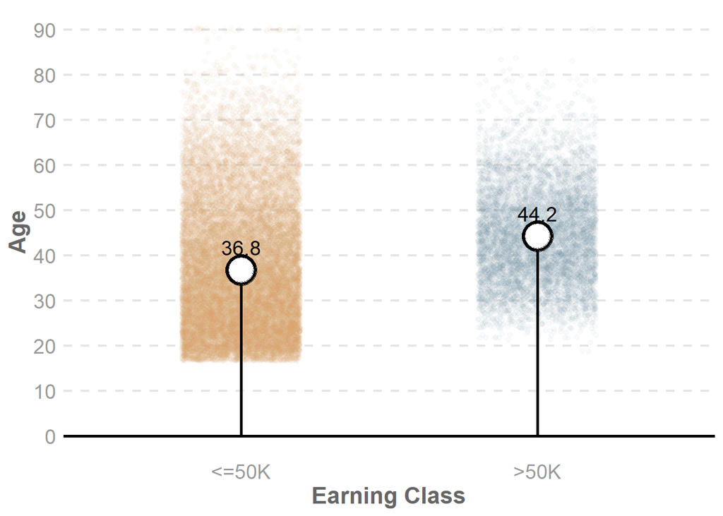

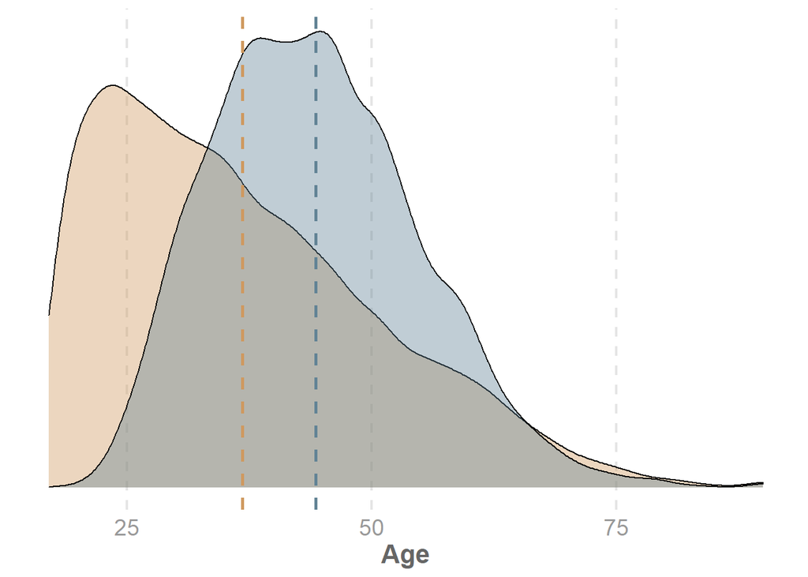

Working from this visual, it is feasible to explore the relationship between the two variables, beginning with a simple logistic regression to identify any perceptible relationship. It is important to note that the presence of a wide array of other variables represents the possibility for many outcomes, and the relationship should **not** be misconstrued as causal at this time:

#### Logistic Model (Earnings Class ~ Age)

```
##
## Call:
## glm(formula = EarningsClassBinary ~ Age, family = "binomial",
##     data = dat_adults)
##
## Deviance Residuals:
##     Min       1Q   Median       3Q      Max
## -1.5367  -0.7635  -0.5963  -0.4871   2.0595
##
## Coefficients:
##               Estimate Std. Error z value Pr(>|z|)
## (Intercept) -2.7439737  0.0427347  -64.21   <2e-16 ***
## Age          0.0395311  0.0009674   40.86   <2e-16 ***
## ---
## Signif. codes:  0 '***' 0.001 '**' 0.01 '*' 0.05 '.' 0.1 ' ' 1
##
## (Dispersion parameter for binomial family taken to be 1)
##
##     Null deviance: 35948  on 32559  degrees of freedom
## Residual deviance: 34201  on 32558  degrees of freedom
## AIC: 34205
##
## Number of Fisher Scoring iterations: 4
```

### Educational Level

The educational level is codified into an ordinal format, allowing us to map educational levels to earnings class using primarily numbers:

```
##       Education EducationNum
## 1     Preschool            1
## 2       1st-4th            2
## 3       5th-6th            3
## 4       7th-8th            4
## 5           9th            5
## 6          10th            6
## 7          11th            7
## 8          12th            8
## 9       HS-grad            9
## 10 Some-college           10
## 11    Assoc-voc           11
## 12   Assoc-acdm           12
## 13    Bachelors           13
## 14      Masters           14
## 15  Prof-school           15
## 16    Doctorate           16
```

Fundamentally, we can then map the educational level to the earnings class to create a similar approach to the analysis for age - showing us the outcomes more clearly:

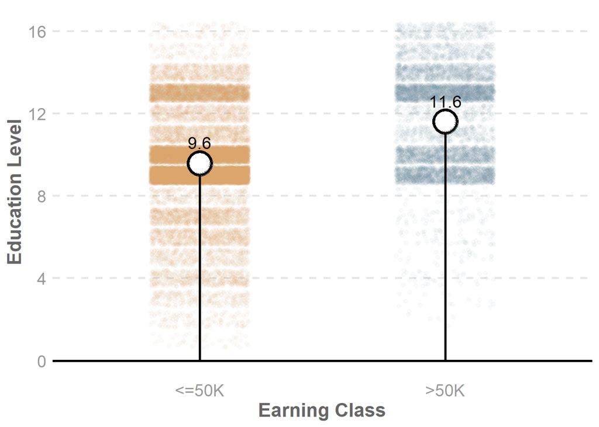

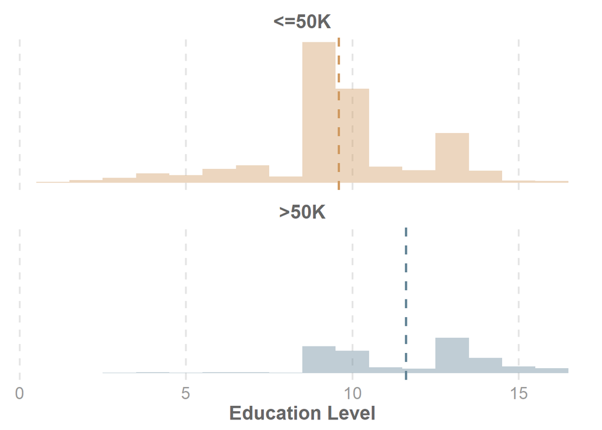

#### Logistic Model (Earnings Class ~ Educational Level)

```
##
## Call:
## glm(formula = EarningsClassBinary ~ EducationNum, family = "binomial",
##     data = dat_adults)
##
## Deviance Residuals:
##     Min       1Q   Median       3Q      Max
## -1.5346  -0.6709  -0.5684  -0.1975   2.9343
##
## Coefficients:
##               Estimate Std. Error z value Pr(>|z|)
## (Intercept)  -5.020012   0.070763  -70.94   <2e-16 ***
## EducationNum  0.364328   0.006277   58.04   <2e-16 ***
## ---
## Signif. codes:  0 '***' 0.001 '**' 0.01 '*' 0.05 '.' 0.1 ' ' 1
##
## (Dispersion parameter for binomial family taken to be 1)
##
##     Null deviance: 35948  on 32559  degrees of freedom
## Residual deviance: 31900  on 32558  degrees of freedom
## AIC: 31904
##
## Number of Fisher Scoring iterations: 4
```

### Hours Worked

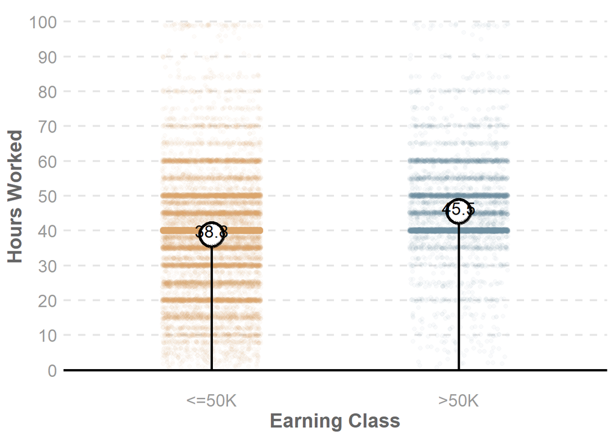

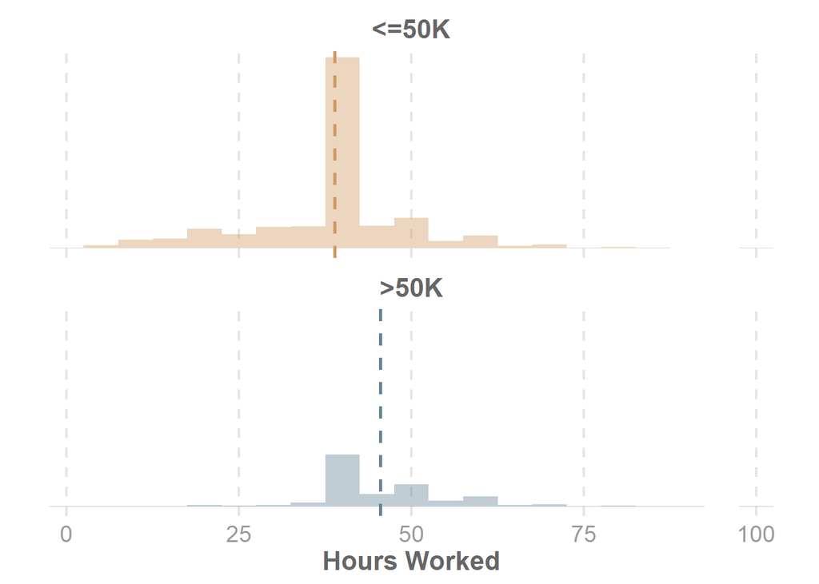

#### Logistic Model (Earnings Class ~ Hours Worked)

```
##
## Call:
## glm(formula = EarningsClassBinary ~ HoursWorked, family = "binomial",
##     data = dat_adults)
##
## Deviance Residuals:
##     Min       1Q   Median       3Q      Max
## -1.8440  -0.7123  -0.7123  -0.3558   2.4898
##
## Coefficients:
##              Estimate Std. Error z value Pr(>|z|)
## (Intercept) -3.099991   0.052897  -58.60   <2e-16 ***
## HoursWorked  0.046449   0.001184   39.22   <2e-16 ***
## ---
## Signif. codes:  0 '***' 0.001 '**' 0.01 '*' 0.05 '.' 0.1 ' ' 1
##
## (Dispersion parameter for binomial family taken to be 1)
##
##     Null deviance: 35948  on 32559  degrees of freedom
## Residual deviance: 34187  on 32558  degrees of freedom
## AIC: 34191
##
## Number of Fisher Scoring iterations: 4
```